#Pemanggilan *Packages*

```r
library(dplyr)
library(TTR)
library(forecast)
library(lmtest) #digunakan untuk uji formal pendeteksian autokorelasi
library(orcutt) #untuk membuat model regresi Cochrane-Orcutt
library(HoRM) #untuk membuat model regresi Hildreth-Lu
```

#Input Data

```r
library(rio)
turbin <- import("https://raw.githubusercontent.com/akabanenabaka/mpdw/main/turbin.csv")
```

#Eksplorasi Data

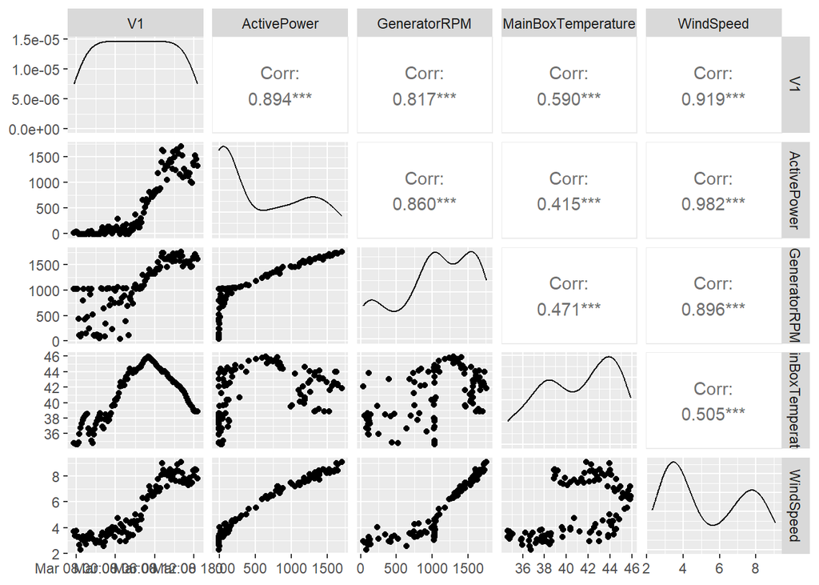

```r
library(ggplot2)
library(GGally)
ggpairs(turbin)
```

#Model Regresi Linear Berganda OLS

```r
model <- lm(ActivePower ~ GeneratorRPM+MainBoxTemperature+WindSpeed, turbin)
summary(model)
```

```
##
## Call:
## lm(formula = ActivePower ~ GeneratorRPM + MainBoxTemperature +
##     WindSpeed, data = turbin)
##
## Residuals:
##      Min       1Q   Median       3Q      Max
## -245.079  -56.232   -6.314   60.421  239.294
##
## Coefficients:
##                      Estimate Std. Error t value Pr(>|t|)
## (Intercept)        -216.92974  119.73250  -1.812   0.0727 .
## GeneratorRPM         -0.10348    0.03958  -2.615   0.0102 *
## MainBoxTemperature  -18.83573    3.17252  -5.937 3.44e-08 ***
## WindSpeed           309.04116    9.75697  31.674  < 2e-16 ***
## ---
## Signif. codes:  0 '***' 0.001 '**' 0.01 '*' 0.05 '.' 0.1 ' ' 1
##
## Residual standard error: 96.16 on 110 degrees of freedom
## Multiple R-squared:  0.9743, Adjusted R-squared:  0.9736
## F-statistic:  1387 on 3 and 110 DF,  p-value: < 2.2e-16
```

#Pengecekan Multikolinearitas

```r
# Pengecekan pertama
library(car)
vif(model)
```

```
##       GeneratorRPM MainBoxTemperature          WindSpeed
##           5.075586           1.344847           5.301340
```

Hasil tersebut menunjukkan nilai *VIF* < 10 sehingga tidak terdapat multikolinieritas pada peubah bebas.

#Uji Normalitas $H_0$: Sisaan menyebar normal $H_1$: Sisaan tidak menyebar normal

```r
# Kolmogorov-Smirnov test
ks.test(model$residuals, "pnorm", mean=mean(model$residuals), sd=sd(model$residuals))
```

```
##
##  Asymptotic one-sample Kolmogorov-Smirnov test
##
## data:  model$residuals
## D = 0.055541, p-value = 0.8734
## alternative hypothesis: two-sided
```

```r
# Shapiro-Wilk normality test
library(car)
shapiro.test(model$residuals)
```

```
##
##  Shapiro-Wilk normality test
##
## data:  model$residuals
## W = 0.98848, p-value = 0.4471
```

Berdasarkan uji formal Saphiro-Wilk dan Kolmogorov-Smirnov didapatkan nilai *p-value* > $\alpha$ (5%). Artinya, cukup bukti untuk menyatakan sisaan berdistribusi normal.

##Sisaan saling bebas $H_0$: tidak ada autokorelasi (sisaan saling bebas) $H_1$: ada autokorelasi (sisaan tidak saling bebas)

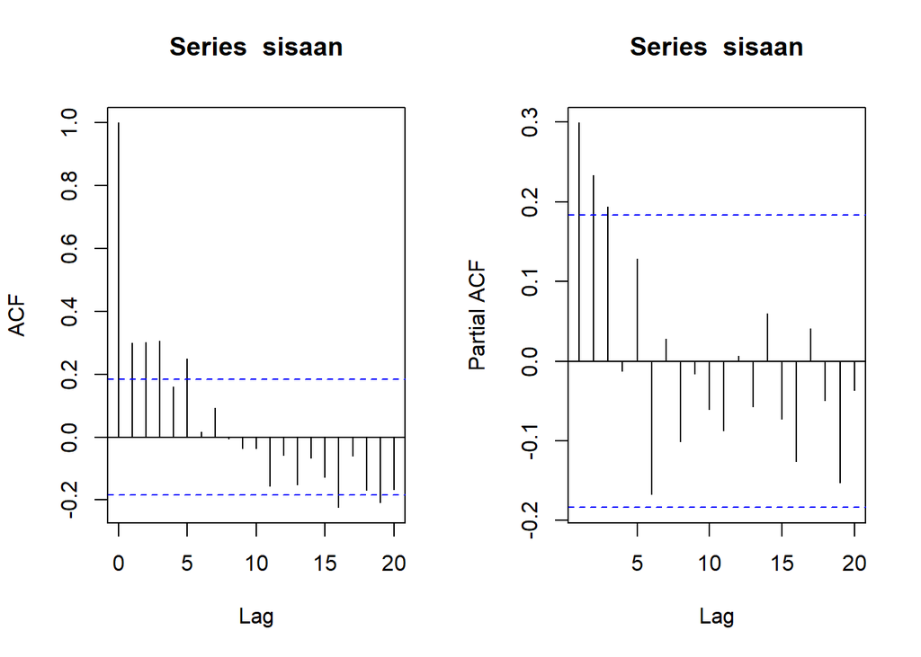

```r
#ACF dan PACF identifikasi autokorelasi
sisaan <- residuals(model)
par(mfrow = c(1,2))
acf(sisaan)
pacf(sisaan)
```

```r
# Runs Test
library(randtests)
runs.test(model$residuals)
```

```
##
##  Runs Test
##
## data:  model$residuals
## statistic = -2.6341, runs = 44, n1 = 57, n2 = 57, n = 114, p-value =
## 0.008436
## alternative hypothesis: nonrandomness
```

```r
# Durbin Watson Test
library(lmtest)
dwtest(model)
```

```
##
##  Durbin-Watson test
##
## data:  model
## DW = 1.3803, p-value = 0.000183
## alternative hypothesis: true autocorrelation is greater than 0
```

```r
# Breusch-Godfrey Test
bgtest(model)
```

```
##
##  Breusch-Godfrey test for serial correlation of order up to 1
##
## data:  model
## LM test = 10.793, df = 1, p-value = 0.001019
```

Berdasarkan plot ACF dan PACF, terlihat terdapat plot yang berada di luar rentang batas yang artinya dapat diperoleh kesimpulan bahwa tolak $H_0$ atau cukup bukti untuk menyatakan bahwa terdapat autokorelasi. Kesimpulan tersebut juga didukung oleh hasil uji formal menggunakan *Runs test*, *Durbin Watson test*, dan *Breusch-Godfrey test* yang menghasilkan *p-value* < $\alpha$=5%. Oleh karena itu, diperlukan penangan autokorelasi. Penanganan yang akan digunakan menggunakan dua metode, yaitu *Cochrane-Orcutt* dan *Hildret-Lu*.

#Penanganan Autokorelasi ##Metode Cochrane-Orcutt

```r
#Penanganan Autokorelasi Cochrane-Orcutt
modelCO<-cochrane.orcutt(model)
modelCO
```

```
## Cochrane-orcutt estimation for first order autocorrelation
##
## Call:
## lm(formula = ActivePower ~ GeneratorRPM + MainBoxTemperature +
##     WindSpeed, data = turbin)
##
##  number of interaction: 13
##  rho 0.367061
##
## Durbin-Watson statistic
## (original):    1.38027 , p-value: 1.83e-04
## (transformed): 2.17167 , p-value: 7.715e-01
##
##  coefficients:
##        (Intercept)       GeneratorRPM MainBoxTemperature          WindSpeed
##        -163.754235          -0.041828         -19.215100         290.247024
```

Hasil keluaran model setelah dilakukan penanganan adalah
$$y_i=-163.754235-0.041828x_1-19.215100x_2+290.247024x_3$$
. Hasil juga menunjukkan nilai *p-value* > 0.05, artinya belum cukup bukti menyatakan bahwa sisaan terdapat autokorelasi pada taraf nyata 5%. Untuk nilai $ρ ̂$ optimum yang digunakan adalah $0.367061$.

```r
#Rho optimum
rho<- modelCO$rho
rho
```

```
## [1] 0.3670605
```

#Transformasi secara manual

```r
ActivePower.trans<- turbin$ActivePower[-1]-turbin$ActivePower[-115]*rho
GeneratorRPM.trans<- turbin$GeneratorRPM[-1]-turbin$GeneratorRPM[-115]*rho
MainBoxTemperature.trans<- turbin$MainBoxTemperature[-1]-turbin$MainBoxTemperature[-115]*rho
WindSpeed.trans<- turbin$WindSpeed[-1]-turbin$WindSpeed[-115]*rho
modelCOmanual<- lm(ActivePower.trans~GeneratorRPM.trans+MainBoxTemperature.trans+WindSpeed.trans)
summary(modelCOmanual)
```

```
##
## Call:
## lm(formula = ActivePower.trans ~ GeneratorRPM.trans + MainBoxTemperature.trans +
##     WindSpeed.trans)
##
## Residuals:
##      Min       1Q   Median       3Q      Max
## -221.638  -55.168   -0.377   47.660  229.763
##
## Coefficients:
##                            Estimate Std. Error t value Pr(>|t|)
## (Intercept)              -128.44249  110.01313  -1.168 0.245525
## GeneratorRPM.trans         -0.04863    0.03914  -1.242 0.216698
## MainBoxTemperature.trans  -18.38091    4.59182  -4.003 0.000114 ***
## WindSpeed.trans           292.27793   10.83782  26.968  < 2e-16 ***
## ---
## Signif. codes:  0 '***' 0.001 '**' 0.01 '*' 0.05 '.' 0.1 ' ' 1
##
## Residual standard error: 90.01 on 110 degrees of freedom
## Multiple R-squared:  0.9492, Adjusted R-squared:  0.9478
## F-statistic: 684.5 on 3 and 110 DF,  p-value: < 2.2e-16
```

#Mencari Penduga Koefisien Regresi setelah Transformasi ke Persamaan Awal

```r
b0bintang <- modelCOmanual$coefficients[1]
b0 <- b0bintang/(1-rho)
b1 <- modelCOmanual$coefficients[2:4]
b0
```

```
## (Intercept)
##   -202.9301
```

```r
b1
```

```
##       GeneratorRPM.trans MainBoxTemperature.trans          WindSpeed.trans
##              -0.04863151             -18.38091027             292.27793416
```

#Metode Hildreth-Lu ##Penanganan Autokorelasi Hildreth lu

```r
hildreth.lu.func<- function(r, model){
  x1 <- model.matrix(model)[,2]
  x2 <- model.matrix(model)[,3]
  x3 <- model.matrix(model)[,4]
  y <- model.response(model.frame(model))
  n <- length(y)
  t <- 2:n
  y <- y[t]-r*y[t-1]
  x1 <- x1[t]-r*x1[t-1]
  x2 <- x2[t]-r*x2[t-1]
  x3 <- x3[t]-r*x3[t-1]

  return(lm(y~x1+x2+x3))
}
```

#Pencarian rho yang meminimumkan SSE

```r
r <- c(seq(0.1,0.9, by= 0.1))
tab <- data.frame("rho" = r, "SSE" = sapply(r, function(i){deviance(hildreth.lu.func(i, model))}))
round(tab, 4)
```

```
##   rho       SSE
## 1 0.1  941369.7
## 2 0.2  905542.5
## 3 0.3  886647.8
## 4 0.4  883936.8
## 5 0.5  896015.8
## 6 0.6  920070.2
## 7 0.7  951038.9
## 8 0.8  982265.0
## 9 0.9 1012182.5
```

Pertama-tama akan dicari di mana kira-kira $ρ$ yang menghasilkan SSE minimum. Pada hasil di atas terlihat $ρ$ minimum ketika 0.4. Namun, hasil tersebut masih kurang teliti sehingga akan dicari kembali $ρ$ yang lebih optimum dengan ketelitian yang lebih. Jika sebelumnya jarak antar $ρ$ yang dicari adalah 0.1, kali ini jarak antar $ρ$ adalah 0.001 dan dilakukan pada selang 0.3 sampai dengan 0.5.

```r
#Rho optimal di sekitar 0.4
rOpt <- seq(0.3,0.5, by= 0.001)
tabOpt <- data.frame("rho" = rOpt, "SSE" = sapply(rOpt, function(i){deviance(hildreth.lu.func(i, model))}))
head(tabOpt[order(tabOpt$SSE),])
```

```
##      rho      SSE
## 68 0.367 883107.7
## 69 0.368 883108.4
## 67 0.366 883108.6
## 70 0.369 883110.7
## 66 0.365 883111.0
## 71 0.370 883114.4
```

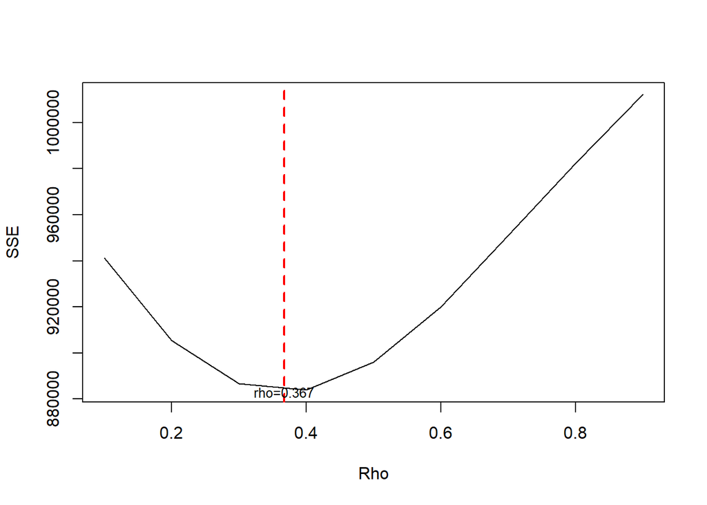

```r
#Grafik SSE optimum
par(mfrow = c(1,1))
plot(tab$SSE ~ tab$rho , type = "l", xlab = "Rho", ylab = "SSE")
abline(v = tabOpt[tabOpt$SSE==min(tabOpt$SSE),"rho"], lty = 2, col="red",lwd=2)
text(x=0.367, y=883107.7, labels = "rho=0.367", cex = 0.8)
```

Perhitungan yang dilakukan aplikasi `R` menunjukkan bahwa nilai $ρ$ optimum, yaitu saat SSE terkecil terdapat pada nilai $ρ=0.367$. Hal tersebut juga ditunjukkan pada plot. Selanjutnya, model dapat didapatkan dengan mengevaluasi nilai $ρ$ ke dalam fungsi `hildreth.lu.func`, serta dilanjutkan dengan pengujian autokorelasi dengan uji Durbin-Watson. Namun, setelah pengecekan tersebut tidak lupa koefisien regresi tersebut digunakan untuk transformasi balik. Persamaan hasil transformasi itulah yang menjadi persamaan sesungguhnya.

```r
#Model terbaik
modelHL <- hildreth.lu.func(0.367, model)
summary(modelHL)
```

```
##
## Call:
## lm(formula = y ~ x1 + x2 + x3)
##
## Residuals:
##      Min       1Q   Median       3Q      Max
## -219.305  -53.196   -1.167   48.571  230.665
##
## Coefficients:
##               Estimate Std. Error t value Pr(>|t|)
## (Intercept) -103.65724  112.76814  -0.919    0.360
## x1            -0.04184    0.03973  -1.053    0.295
## x2           -19.21535    4.66640  -4.118 7.47e-05 ***
## x3           290.25074   11.02572  26.325  < 2e-16 ***
## ---
## Signif. codes:  0 '***' 0.001 '**' 0.01 '*' 0.05 '.' 0.1 ' ' 1
##
## Residual standard error: 90.01 on 109 degrees of freedom
## Multiple R-squared:  0.9476, Adjusted R-squared:  0.9462
## F-statistic: 657.5 on 3 and 109 DF,  p-value: < 2.2e-16
```

```r
#Transformasi Balik
cat("y = ", coef(modelHL)[1]/(1-0.367), "+", coef(modelHL)[2],"x1","+", coef(modelHL)[3],"x2","+", coef(modelHL)[4],"x3", sep = "")
```

```
## y = -163.7555+-0.04183626x1+-19.21535x2+290.2507x3
```

Setelah dilakukan tranformasi balik, didapatkan model dengan metode Hildreth-Lu sebagai berikut.
$$y_i=-163.7555-0.04183626x1x_1-19.21535x_2+290.2507x_3$$

```r
#Deteksi autokorelasi
dwtest(modelHL)
```

```
##
##  Durbin-Watson test
##
## data:  modelHL
## DW = 2.1715, p-value = 0.7713
## alternative hypothesis: true autocorrelation is greater than 0
```

Hasil uji *Durbin-Watson* juga menunjukkan bawah nilai *p-value* sebesar $0.7713$, di mana *p-value* > $\alpha$=5%. Artinya tak tolak $H_0$ atau belum cukup bukti menyatakan bahwa terdapat autokorelasi dengan metode *Hildreth-Lu* pada taraf nyata 5%.

Terakhir, akan dibandingkan nilai SSE dari ketiga metode (metode awal, metode Cochrane-Orcutt, dan Hildreth-Lu).

```r
sseModelawal <- anova(model)$`Sum Sq`[-(1:3)]
sseModelCO <- anova(modelCOmanual)$`Sum Sq`[-(1:3)]
sseModelHL <- anova(modelHL)$`Sum Sq`[-(1:3)]
mseModelawal <- sseModelawal/length(turbin$ActivePower)
mseModelCO <- sseModelCO/length(turbin$ActivePower)
mseModelHL <- sseModelHL/length(turbin$ActivePower)
akurasi <- matrix(c(sseModelawal,sseModelCO,sseModelHL,
                    mseModelawal,mseModelCO,mseModelHL),nrow=2,ncol=3,byrow = T)
colnames(akurasi) <- c("Model Awal", "Model Cochrane-Orcutt", "Model Hildreth-Lu")
row.names(akurasi) <- c("SSE","MSE")
akurasi
```

```
##     Model Awal Model Cochrane-Orcutt Model Hildreth-Lu
## SSE 1017168.47            891222.836        883107.750
## MSE    8922.53              7817.744          7746.559
```

# Simpulan

Autokorelasi yang terdapat pada data Active Power terjadi akibat adanya korelasi di antara unsur penyusunnya. Indikator Active Power yang erat hubungannya dengan komponen-komponen pada turbin dan kecepatan angin sangat rawan menjadi penyebab adanya autokorelasi. Adanya autokorelasi menyebabkan model regresi kurang baik karena akan meingkatkan galatnya. Autokorelasi dapat dideteksi secara eksploratif melalui plot sisaan, ACF, dan PACF, serta dengan uji formal Durbin-Watson. Namun, autokorelasi tersebut dapat ditangani dengan metode Cochrane-Orcutt dan Hildreth-Lu. Disarankan menggunakan metode Hildreth-Lu karena menghasilkan nilai SSE terkecil.